# Decision Trees

# Exercise 7 - Boosted Tree

```r
library(gbm)
```

We use the gbm package and within it the gbm() function to fit boosted regression trees to the Boston data set.

Perform boosting on the training data set, treating this as a regression problem.

```r
set.seed(1)
boost.boston = gbm(medv ~ ., data = Boston[train,], distribution = "gaussian", n.trees = 5000, interaction.depth = 4)
```

We run gbm() with the option distribution = “gaussian” since this is a regression problem. if it were a binary classification problem, we would use distribution = “bernoulli” “interaction.depth” refers to the maximum depth of variable interactions. 1 implies an additive model 2 implies a model with 2-way interactions, etc.

|  | var | rel.inf |
| --- | --- | --- |
| rm | rm | 43.9919329 |
| lstat | lstat | 33.1216941 |
| crim | crim | 4.2604167 |
| dis | dis | 4.0111090 |
| nox | nox | 3.4353017 |
| black | black | 2.8267554 |
| age | age | 2.6113938 |
| ptratio | ptratio | 2.5403035 |
| tax | tax | 1.4565654 |
| indus | indus | 0.8008740 |

[output cut: 3 more lines]

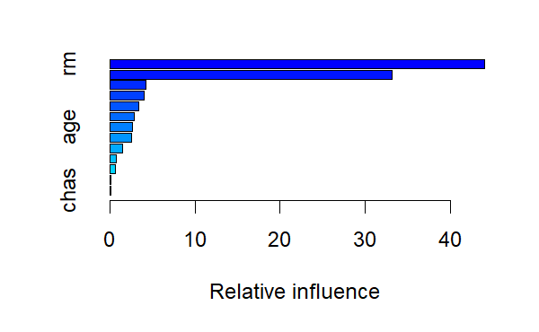

We see that lstat and rm are by far the most important variables (again)

Produce partial dependence plots for these two variables (lstat and rm)

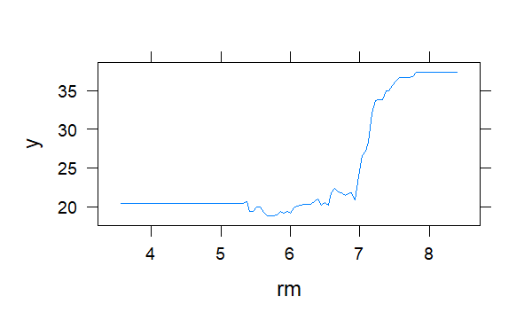

```r
par(mfrow=c(1,2))
plot(boost.boston, i = "rm")
```

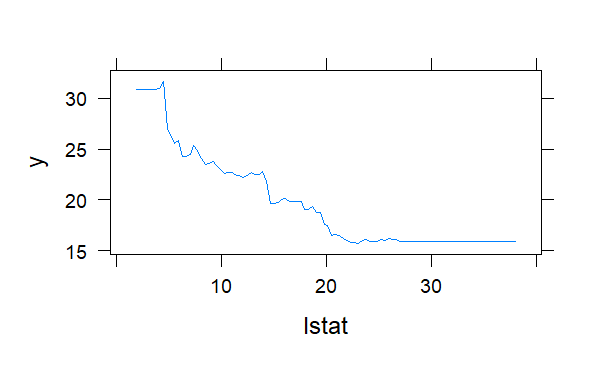

```r
plot(boost.boston, i = "lstat")
par(mfrow=c(1,1))
```

These plots illustrate the marginal effect of the selected variables on the response after integrating out the other variables. i.e., for every value of the selected variable, we calculate the predicted response for every combination of vallues of the other variables. We then average (“integrate out”) over all these predicted responses. We do that for each value of the selected variable, which gives the graph. As we might expect, median house prices are increasing with rm and decreasing with lstat.

Now use the boosted model to predict medv on the test set. Report the MSE

```r
yhat.boost=predict(boost.boston, newdata=Boston[-train,], n.trees=5000)
mean((yhat.boost-boston.test)^2)
```

```
[1] 18.84709
```

The test MSE is 18.847, similar to random forest but lower than bagging.

What happens if we vary the shrinkage parameter from its default of 0.001 to 0.2? Report the test MSE.

```r
boost.boston = gbm(medv ~ ., data = Boston[train,], distribution = "gaussian", n.trees = 5000, interaction.depth = 4, shrinkage = 0.2, verbose = F)
yhat.boost=predict(boost.boston, newdata=Boston[-train,], n.trees=5000)
mean((yhat.boost-boston.test)^2)
```

```
[1] 18.33455
```

In this case, using lambda = 0.2 leads to a slightly lower test MSE than lambda = 0.001.